# More Backtracking Algorithms

January 29, 2021

# Assignment Comments, Sample Solutions

## All the cuts tried by CutChurro

```
Cuts:   Price:
1111    4
112     7
121     7
13      9
211     7
22      10
31      9
4       9
```

- When $n = 4$, there are three places to make (or not make) a cut.
- So you have 3 independent decisions to make in sequence, each with two options (cut or don’t cut):
  - $2^3 = 8$ ways to cut the churro into pieces.
- `CutChurro` is calculating by *recursive brute force*. (not clever)

## CutChurro Time, counting nonrecursive call

```javascript
// Let price[1..n] be a constant array of prices.
// So price[i] is the cost of a churro of length i.

CutChurro(n):
    if n = 0
        return 0
    maxTotPrice <- -1
    for i <- 1 to n
        totPriceTry <- price[i] + CutChurro(n-i)
        if totPriceTry > maxTotPrice
            maxTotPrice <- totPriceTry
    return maxTotPrice
```

Count the original call as one call, so `CutChurro(0)` makes 1 `CutChurro` call:

$$\begin{align}
C(0) &= 1\\
C(n) &= C(n-1) + C(n-2) + \cdots + C(1) + C(0) + 1
\end{align}$$

## Guess a closed-form solution

$$\begin{align}
C(0) &= 1\\
C(n) &= C(n-1) + C(n-2) + \cdots + C(1) + C(0) + 1
\end{align}$$

Compute the first few terms and you get: $1,2,4,8,\ldots$, so it looks like the closed-form formula is going to be $C(n) = 2^n$. Can we prove this?

## Trick: Subtract and cancel

$$\begin{align}
C(n) - C(n-1) &= [C(n-1) + C(n-2) + \cdots + C(1)+ C(0)+ 1] \\
&\phantom{=[C(n-1)} - [C(n-2) + \cdots + C(1) + C(0) + 1] \\
& = C(n-1)
\end{align}$$

So we get $C(n) = 2C(n-1)$, and it is easy to prove by induction that $C(n) = 2^n$.

## Inductive argument

- Base case: `CutChurro(0)` makes one call.
- Suppose as *inductive hypothesis* that `CutChurro(k)` makes $2^k$ calls, for $k<n$.
- `CutChurro(n)` calls `CutChurro(n-1)`, `CutChurro(n-2)`, …, `CutChurro(1)`, `CutChurro(0)`, so by inductive hypothesis, it makes $2^{n-1} + 2^{n-2} + \cdots + 2 + 1 + 1$ calls (counting the original call itself). By the same subtract-and-cancel trick, this equals $2^n$.

## Aside: Inductive correctness proof

- Base case: `CutChurro(0)` is zero, which is the maximum price you can get for nothing at all.
- Suppose as *inductive hypothesis* that `CutChurro(k)` **returns the maximum price** you can get for a $k$-inch churro by cutting it up, for $k<n$.
- `CutChurro(n)` computes the maximum price obtained by cutting a piece of size $0,1,\ldots n-1$ and then, by inductive hypothesis, maximizing the total price of the other piece. Therefore `CutChurro(n)` **returns the maximum price**.

In an inductive proof, your inductive hypothesis should look like the final conclusion of your proof.

## CutChurro Time, recursive calls only

$$\begin{align}
C(0) &= 0\\
C(n) &= n + \sum\limits_{i=1}^n C(n-i)\\
&= n + C(n-1) + \sum\limits_{i=1}^{n-1} C(n-1-i)\\
&= n + C(n-1) + C(n-1) - (n-1) \\
&= 1 + 2C(n-1)
\end{align}$$

Closed-form solution: $C(n) = 2^n - 1$

## CutChurro Timing

```r
num_inches <- 10:20
elapsed_time = sapply(num_inches,function(n){system.time(CutChurro(n))['elapsed']} )
rbind(num_inches, elapsed_time)
```

```
             elapsed elapsed elapsed elapsed elapsed elapsed elapsed elapsed
num_inches        10  11.000  12.000  13.000  14.000  15.000  16.000  17.000
elapsed_time       0   0.003   0.005   0.009   0.013   0.023   0.044   0.087
             elapsed elapsed elapsed
num_inches    18.000  19.000  20.000
elapsed_time   0.163   0.354   0.667
```

## Plot of times

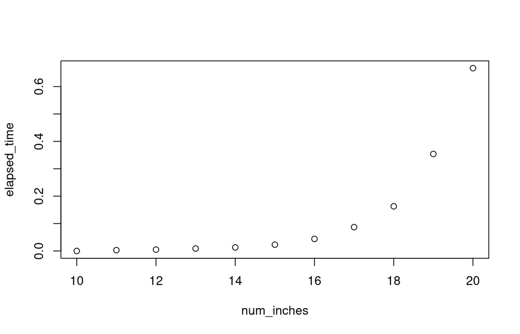

```r
plot(num_inches, elapsed_time)
```

# More Backtracking Examples

## General Idea

- Problem has several options, and *recursive substructure.*
- Try one of the options, and solve the subproblem recursively.
  - If that doesn’t work, try another option.

Backtracking algorithms tend to be slow.

## Decision Problems

- A *decision problem* is a problem whose answer is either TRUE or FALSE.
- Lots of basic questions about algorithms involve decision problems.
- Often an algorithm that solves a decision problem can be modified slightly to do something that seems harder.

Example:

- Decision problem: Does $p(x) = Ax^2 + Bx +C$ have any roots?
- Slightly harder problem: Find all the roots of $p(x) = Ax^2 + Bx +C$.

Meta-Example:

- Decision problem: Does $\mathcal{X}$ have a solution?
- Slightly harder problem: Give all the solutions of $\mathcal{X}$.

# Text Segmentation

## Example: Text Segmentation

- We have a boolean function `IsWord(A[1..i])` that tells us if a string (i.e., array) is a word in our language.
- We have a string of words without spaces.
- Can the string be *segmented* into words? (Is it “splittable”?)

```
BOTHEARTHANDSATURNSPIN

BOT HEART HANDS AT URNS PIN

BOTH EARTH AND SATURN SPIN
```

## Recursive substructure

If a string starts with a word, and the rest of the string is splittable into words, then whole string is splittable.

- See if the first letter is a word.
  - Recursively check the rest.
- See if the first two letters make a word.
  - Recursively check the rest.
- See if the first three letters make a word.
  - Recursively check the rest.
- … and so on.

## Text Segmentation Algorithm

```javascript
Splittable(A[1..n]):
    if n = 0
        return TRUE
    for i <- 1 to n
        if IsWord(A[1..i])
            if Splittable(A[(i+1)..n])
                return TRUE
    return FALSE
```

Time? (Same recurrence as CutChurro: $O(2^n)$).

## Global Variables

- Is usually *not OK* to use global variables when programming.
- It is actually **OK** to use global variables when describing algorithms.
  - Often global variables make our descriptions cleaner.
  - We assume a “competent programmer who is not quite as clever as we are” could read our algorithm description and implement it without global variables.

## Text Segmentation Algorithm: Index only version

```javascript
// A[1..n] is a string to test to see if it is splittable. (n is constant)
// IsWord(i,j) returns true iff A[i..j] is a word.

Splittable(i):    << Is A[i..n] splittable? >>
    if i > n
        return TRUE
    for j <- i to n
        if IsWord(i, j)
            if Splittable(j+1)
                return TRUE
    return FALSE


// Call this function as: Splittable(1)
```

# Subset Sum

## Example: Subset Sum

- We have a *set* $X$ of positive integers (so no duplicates).
- Given a *target* value $T$, is there some *subset* of $X$ that adds up to $T$?

Recursive Substructure:

- For any $x\in X$, the answer is TRUE for target $T$ if
  - The answer is TRUE for $X \setminus \{x\}$ and target $T$, or
  - The answer is TRUE for $X \setminus \{x\}$ and target $T-x$.
- In other words, the cases are:
  - *without:* There is a subset not containing $x$ that works.
  - *with:* There is a subset containing $x$ that works.
- Base Cases:
  - If $T = 0$, the answer is TRUE. ($\emptyset$ works!)
  - If $T < 0$, the answer is FALSE. (everything’s positive)
  - If $X = \emptyset$, the answer if FALSE (unless $T=0$, of course.)

## Subset Sum Algorithm: Set version

Form the subproblems by removing *some* element of $X$.

```javascript
SubsetSum(X, T):   //  Does any subset of X sum to T?
    if T = 0
        return TRUE
    else if T < 0 or X = ∅
        return FALSE
    else
        x <- any element of X
        with <- SubsetSum(X \ {x}, T − x)
        wout <- SubsetSum(X \ {x}, T)
        return (with OR wout)
```

## Table Groups

| Table #1 | Table #2 | Table #3 | Table #4 | Table #5 | Table #6 | Table #7 |
| --- | --- | --- | --- | --- | --- | --- |
| Drake | Trevor | Kevin | Levi | Claire | Jordan | Talia |
| Isaac | John | Grace | Bri | James | Ethan | Josiah |
| Graham | Blake | Nathan | Jack | Kristen | Andrew | Logan |

## Subset Sum: Array index version

1. Complete the array index version of `SubsetSum`. Form the subproblems by removing the *last* element of $X$.

```javascript
// X[1..n] is an array of positive integers (n is constant)

SubsetSum(i, T) :  //  Does any subset of X[1..i] sum to T?
{
    TODO
}


// Call this function as: SubsetSum(n, T)
```

2. Come up with a recurrence for the number of `SubsetSum` calls made by `SubsetSum(n)`. Do you recognize it? What’s the closed-form solution?

## Slightly Harder Problem

3. Can you modify the algorithm from #1 so that it returns the *number* of subsets of $X$ that add up to $T$, instead of just TRUE or FALSE?